# Geospatial Data & Maps in R, pt 3

October 2018

## Part III Prep

1. https://github.com/dlab-geo/r-geospatial-workshop
- Click *Clone or Download* and download the zip file
- Upzip the zip file and make a note of the folder in which it is located
1. Open RStudio and start a **new script** or continue the one from last week
2. Set your working directory to where you downloaded and unzipped the files
3. Follow along by opening `r-geospatial-workshop-pt3.html` in a web browser
4. Make sure required libraries are installed.
- sp, rgdal, rgeos, tmap, ggplot2, RColorbrewer, classInt, raster

## Follow Along

Open one of the tutorial files in a web browser

Slides `r-geospatial-workshop-pt3.html`

Tutorial `r-geospatial-workshop-pt3-tutorial.html`

R Code `scripts/r-geospatial-workshop-pt3.Rmd`

*Make sure you can cut and paste into RStudio*

## Part III Overview

Review basic raster concepts

Read in our previous spatial data and new raster data

Make some raster and combined raster-vector maps

Run some raster and raster-vector operations and analyses

## R Spatial Libraries

Let's load the libraries we will use

```r
library(sp)     # spatial objects and methods
library(rgdal)  # read/write from file; manage CRSs
library(rgeos)  # geometric operations
library(tmap)   # mapping spatial objects
library(raster) # reading in and operating on rasters
```

## Set your working directory

Use `setwd` to set your working directory to the location of the tutorial files.

For example:

```r
path = "/path/to/your/working_directory"
setwd(path)
```

## Load files from Parts I and II

## SF Census Tracts

```r
# Read in the 'sftracts_wpop' shapefile
tracts = readOGR('./data', 'sftracts_wpop')
```

## SF Properties 2015

```r
# Read in from CSV file
print(list.files())
```

```
##  [1] "data"
##  [2] "drafts"
##  [3] "Geospatial_Data_in_R_prep.docx"
##  [4] "images"
##  [5] "index.html"
##  [6] "output"
##  [7] "previous_versions"
##  [8] "r-geospatial-cheatsheet.html"
##  [9] "r-geospatial-cheatsheet.Rmd"
## [10] "r-geospatial-workshop-pt1-fall2018.html"
## [11] "r-geospatial-workshop-pt1-fall2018.Rmd"
## [12] "r-geospatial-workshop-pt1-tutorial.html"
## [13] "r-geospatial-workshop-pt1-tutorial.Rmd"
## [14] "r-geospatial-workshop-pt1.html"
## [15] "r-geospatial-workshop-pt1.Rmd"
## [16] "r-geospatial-workshop-pt2-tutorial.html"
## [17] "r-geospatial-workshop-pt2-tutorial.Rmd"
## [18] "r-geospatial-workshop-pt2.html"
## [19] "r-geospatial-workshop-pt2.Rmd"
## [20] "r-geospatial-workshop-pt3.html"
## [21] "r-geospatial-workshop-pt3.Rmd"
## [22] "README.md"
## [23] "scripts"
## [24] "sf_properties.html"
## [25] "sf_properties.png"
```

```r
sfhomes <- read.csv('./data/sf_properties.csv',
                    stringsAsFactors = FALSE)
# subset the data
sfhomes15 <- subset(sfhomes, as.numeric(SalesYear) == 2015)

sfhomes15_sp <- sfhomes15  # Make a copy

# Make it spatial
coordinates(sfhomes15_sp) <- c('lon','lat')

#Assign it a proj4string using the EPSG code
proj4string(sfhomes15_sp) <- CRS("+init=epsg:4326")

#Reproject to the tracts projection
#NOTE: We're overwriting the previous sfhomes15_sp object here! This is
#fine to do if we want, but we should always beware.
sfhomes15_sp = spTransform(sfhomes15_sp, CRS(proj4string(tracts)))

#check projection equality
proj4string(sfhomes15_sp) == proj4string(tracts)
```

```
## [1] TRUE
```

## SF Boundary

Read in the `sf_boundary.shp` file with `rGDAL`

```r
sfboundary <- readOGR(dsn="data", layer="sf_boundary")
#transform it to match the tracts projection
sfboundary_lonlat = spTransform(sfboundary, CRS(proj4string(tracts)))

proj4string(sfboundary_lonlat) == proj4string(tracts)
```

```
## [1] TRUE
```

## SECTION I: Raster Data in R

## Read in a Raster

Using the fabulous `raster` package

```r
# Reading in and plotting raster files

#read in a Bay Area DEM (Digital Elevation Model)
#(from http://www.webgis.com/terr_pages/CA/dem1/sanfrancisco.html)
DEM = raster('./data/san_francisco-e.DEM')
```

## Plot it

Make a quick map of the data to check it out

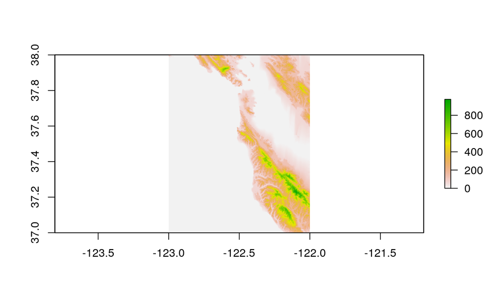

```r
#plot it
plot(DEM)
```

## Explore the Structure

Just enter the name of the raster to see a summary of its structure. You can view more detail in the RStudio Environment pane.

```r
DEM
```

```
## class       : RasterLayer
## dimensions  : 1201, 1201, 1442401  (nrow, ncol, ncell)
## resolution  : 0.0008333333, 0.0008333333  (x, y)
## extent      : -123.0004, -121.9996, 36.99958, 38.00042  (xmin, xmax, ymin, ymax)
## coord. ref. : +proj=longlat +datum=NAD27 +no_defs +ellps=clrk66 +nadgrids=@conus,@alaska,@ntv2_0.gsb,@ntv1_can.dat
## data source : /home/ihavehands/Desktop/stuff/berk/dlab/r-geospatial-workshop/data/san_francisco-e.DEM
## names       : san_francisco.e
## values      : -32768, 32767  (min, max)
```

## CRS Transformations

Check the CRS (aka projection) of the DEM raster data.

Transform (or reproject) the Tracts vector data to match it.

```r
#check out its projection
proj4string(DEM)
```

```
## [1] "+proj=longlat +datum=NAD27 +no_defs +ellps=clrk66 +nadgrids=@conus,@alaska,@ntv2_0.gsb,@ntv1_can.dat"
```

```r
#reproject tracts and sfboundary to our DEM projection
tracts_NAD = spTransform(tracts, CRS(proj4string(DEM)))
sfboundary_NAD = spTransform(sfboundary_lonlat, CRS(proj4string(DEM)))
```

## CRS Transformations

You can reproject the DEM with `raster::projectRaster`

Note how the syntax is similar to `sp::spTransform`

```r
DEM_WGS = projectRaster(DEM, projectExtent(DEM, CRS(proj4string(tracts))))

# Now let's check equivalence
proj4string(tracts_NAD) == proj4string(DEM)
```

```
## [1] TRUE
```

```r
proj4string(DEM_WGS) == proj4string(tracts)
```

```
## [1] TRUE
```

## Clipping Rasters

Since the raster data covers a larger area than our vector data / area of interest, we can clip it.

```r
# clip the WGS CRS version of the rasters to tracts
DEM_WGS_crop = crop(DEM_WGS, extent(tracts))

# Clip the NAD CRS version
DEM_crop = crop(DEM, extent(tracts_NAD))
```

## Plot Clipped Raster data

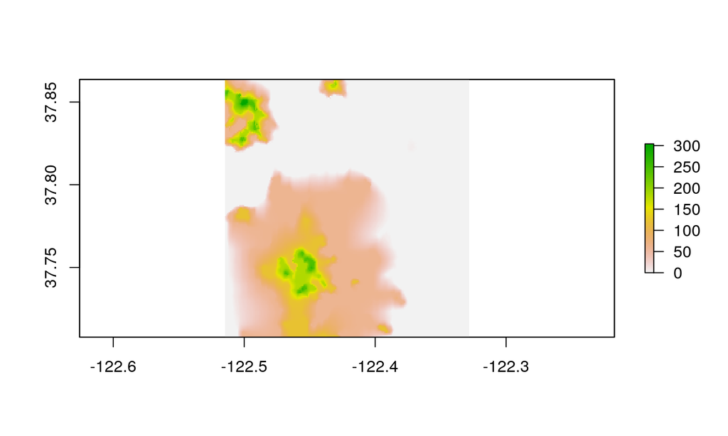

```r
plot(DEM_WGS_crop)
```

## Plot Raster & Vector Data

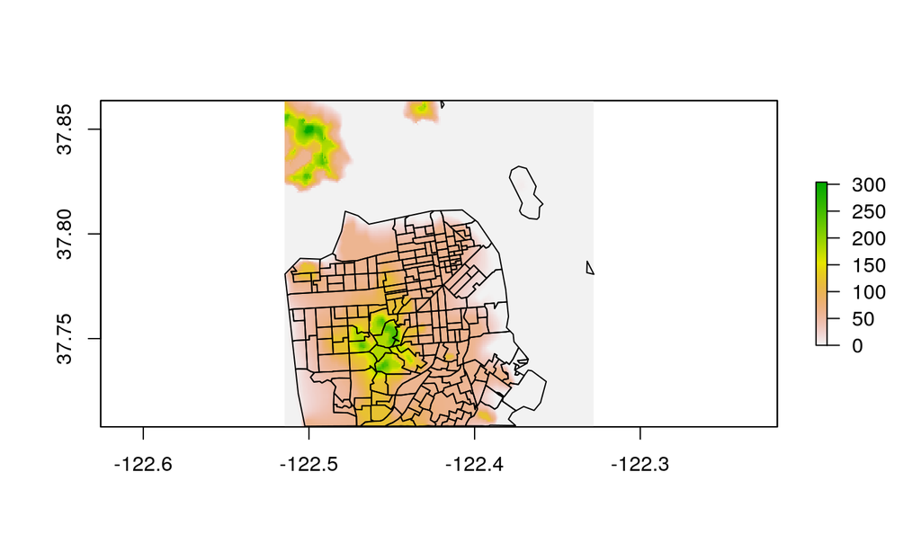

```r
#plot together
plot(DEM_WGS_crop)
plot(tracts, add = T)
```

## Let's plot these in TMAP

We can make an interactivelyplot using `TMAP`

```r
my_map <- tm_shape(DEM_WGS_crop) +
  tm_raster() +
tm_shape(tracts) +
  tm_borders() +

# Set mode to interactive
tmap_mode("view")
```

```
## tmap mode set to interactive viewing
```

## View Map

```r
my_map
```

[interactive chart not shown]

## Extract elevation values

We can use the raster::extract function to get the elevation values for each tract.

```r
# get the elevation for every cell in each of the census tracts
elev = extract(DEM_WGS_crop, tracts)

#what did that give us?
head(elev)
```

```
## [[1]]
##  [1] 55.97961 57.98517 57.98980 58.99490 58.99491 58.99491 59.99493
##  [8] 59.99492 59.99492 59.99491 59.99998 60.00000 60.00000 60.00000
## [15] 60.00000 60.00000 60.00000 60.00000 60.00000 60.00000 60.00000
## [22] 60.00000 60.00000 60.00000 60.00000 60.00000 60.00000 60.00000
##
## [[2]]
##  [1] 59.00984 59.00487 59.00488 59.00002 59.00002 59.00000 58.00979
##  [8] 58.00487 58.00984 58.00485 58.00002 57.00977
##
## [[3]]
##  [1] 57.98527 57.99014 57.99016 57.99015 59.00039 58.99510 58.99509
##  [8] 58.99508 59.99514 59.99511 59.99510 59.99510 60.00000 60.00000
## [15] 60.00000 60.00000 60.00000 60.00000 60.00000 60.00000 60.00000
## [22] 60.00000 60.00000 60.00000 60.00000 60.00000 60.00000 60.00000
## [29] 60.00000 60.00000 60.00000 60.00000 60.00000 60.00000 60.00000
## [36] 60.00000
##
## [[4]]
##  [1] 60 60 60 60 60 60 60 60 60 60 60 60 60 60 60 60 60 60 60 60 60 60 60
## [24] 60 60 60 60 60 60 60 60 60 60 60
##
## [[5]]
##  [1] 60 60 60 60 60 60 60 60 60 60 60 60 60 60 60 60 60 60 60 60 60 60 60
## [24] 60 60 60 60 60 60 60 60 60 60 60 60 60 60 60 60 60 60 60 60 60 60 60
## [47] 60
##
## [[6]]
##  [1] 60 60 60 60 60 60 60 60 60 60 60 60 60 60 60 60 60 60 60 60 60 60 60
## [24] 60 60 60 60 60 60 60 60 60 60 60 60 60
```

## What is the output?

Check out the data in the `elev` object

```r
length(elev)
```

```
## [1] 195
```

```r
nrow(tracts)
```

```
## [1] 195
```

## What is the output?

A vector of the elevations for all the cells within each census tract!

```r
length(elev)
```

```
## [1] 195
```

```r
nrow(tracts)
```

```
## [1] 195
```

## Average Raster value by Vector shape

Let's get each tract's average elevation

```r
mean_elev = lapply(elev, mean, na.rm = T)
head(mean_elev)
```

```
## [[1]]
## [1] 59.60425
##
## [[2]]
## [1] 58.42156
##
## [[3]]
## [1] 59.6645
##
## [[4]]
## [1] 60
##
## [[5]]
## [1] 60
##
## [[6]]
## [1] 60
```

## Add elevation to Vector object

```r
tracts$mean_elev = unlist(mean_elev)
```

## Map it

```r
#what did we get?
elev_map <- tm_shape(tracts) +
  tm_polygons(col = 'mean_elev') +
  tm_layout("The pain of biking in SF, by census tract",
            inner.margins=c(0,0,.1,0), title.size=4.8)
```

## Map it

```r
elev_map
```

[interactive chart not shown]

## One step Re-do

We can also pass a function argument to `raster::extract`

```r
elev = extract(DEM_WGS_crop, tracts, fun=mean)

#what did that give us?
head(elev)
```

```
##          [,1]
## [1,] 59.60425
## [2,] 58.42156
## [3,] 59.66450
## [4,] 60.00000
## [5,] 60.00000
## [6,] 60.00000
```

## Questions?

Can you see the difference between mapping a vector layer on top of a raster layer (my_map) compared to summarizing raster values by vector polygons and then mapping the polygon features (elev_map)?

## SECTION II: Categorical Rasters, Reclassifying, and Spatial Analysis

## Challenge section

This section will feature a number of challenges, to get you practicing some of the material we've already covered today.

## Challenge 1: Read in and check out new data

You have another raster dataset in your `./data` directory. The file is called `nlcd2011_sf.tif`. This is data from the National Land Cover Database (NLCD; https://www.mrlc.gov/nlcd11_leg.php). It's 2011 data that was downloaded from https://viewer.nationalmap.gov/basic. Read that file in as an object called `nlcd`, and plot it.

## Work in progress…

## Solution

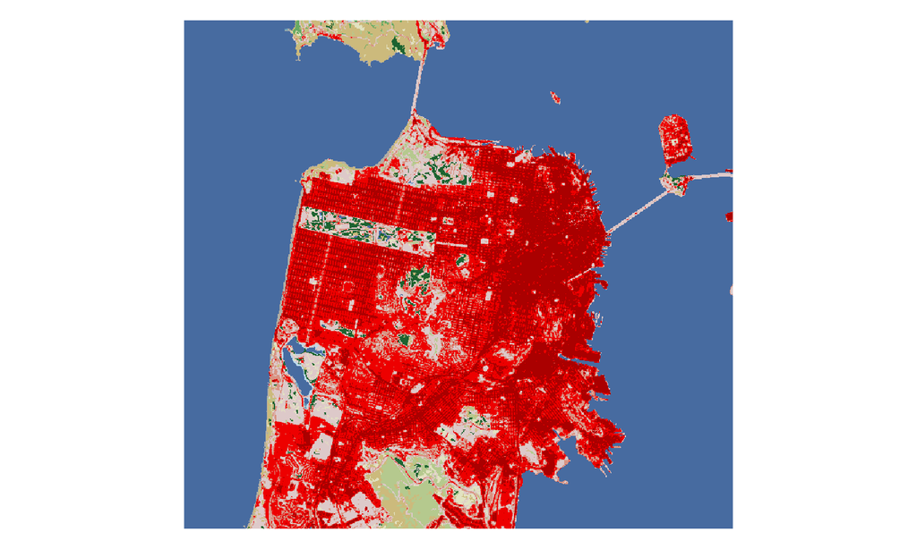

```r
#read in nlcd data
nlcd = raster('./data/nlcd2011_sf.tif')

#plot nlcd
plot(nlcd)
```

## Let's also take a look at a summary of the NLCD data

```r
summary(nlcd)
```

```
##         nlcd2011_sf
## Min.             11
## 1st Qu.          11
## Median           11
## 3rd Qu.          23
## Max.             95
## NA's              0
```

## … and a barplot

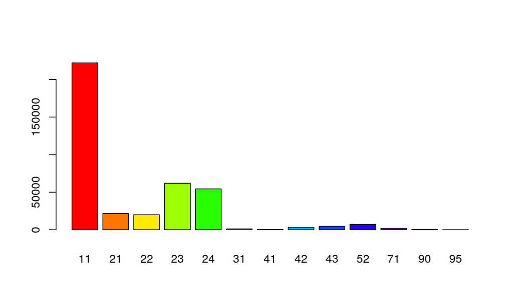

```r
barplot(nlcd)
```

## What do those values mean?

This is a categorical raster. Each cell on the raster holds a discrete (integer) value, coding a particular type of land-cover (rather than a continuous value, like we saw with our elevation data above).

Where do we do to figure out what the codes mean? This should come with the metadata that ships with your data. [Here] (https://www.mrlc.gov/nlcd11_leg.php) is a layout of the NLCD codes.

## Challenge 2: Reproject and crop our NLCD data

Now that we've read in our NCLD data, check if we need to reproject it (we want it to be in the same projection as our `tracts` object), and project it if need be. Then crop it to the extent of our `tracts` object.

## Work in progress…

## Solution

```r
#check projection equality
proj4string(nlcd) == proj4string(tracts)
```

```
## [1] FALSE
```

```r
#reproject
nlcd_WGS = projectRaster(nlcd, projectExtent(nlcd, CRS(proj4string(tracts))))

#check projection equality again
proj4string(nlcd_WGS) == proj4string(tracts)
```

```
## [1] TRUE
```

```r
#crop
nlcd_WGS_crop = crop(nlcd_WGS, extent(tracts))
```

## Reclassifying categorical rasters

When we're working with a categorical raster, we'll often want to reclass our data. We may want to do this because:

- Our original data has more classifications than we actually need for our analysis.
- We want to represent the classifications we do have by a different numerical scheme because it somehow makes our analysis more convenient.

## Reclass the NLCD

Let's reclass our NLCD data. First we'll need to define a reclassification matrix with 3 columns (low, high, to):

```r
?reclassify
```

## Define reclassification matrix

```r
reclass_df <- c(0, 12, NA, # water will be set to NA (i.e. 'left out' of our analysis)
                20, 30, 0, # developed and hardscape will have 0s
                30, 32, 0,
                40, Inf, 1) # greensapce will have 1s
reclass_df
```

```
##  [1]   0  12  NA  20  30   0  30  32   0  40 Inf   1
```

```r
reclass_m <- matrix(reclass_df, ncol = 3, byrow = TRUE)
reclass_m
```

```
##      [,1] [,2] [,3]
## [1,]    0   12   NA
## [2,]   20   30    0
## [3,]   30   32    0
## [4,]   40  Inf    1
```

## Reclassify the raster

```r
nlcd_green <- reclassify(nlcd, reclass_m)

freq(nlcd_green)
```

```
##      value  count
## [1,]     0 159228
## [2,]     1  18089
## [3,]    NA 222187
```

## Reclassify the raster

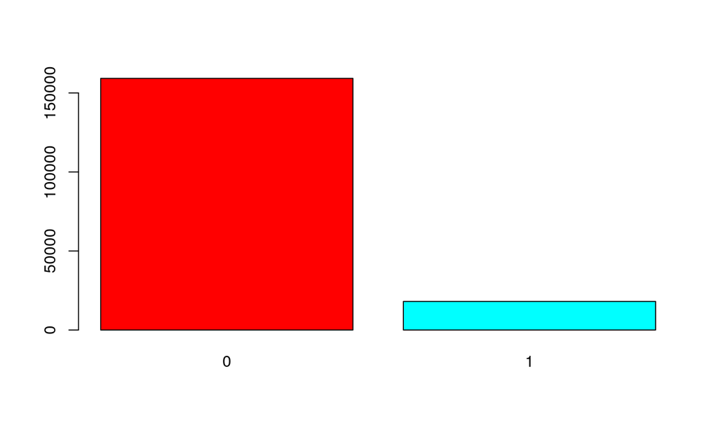

```r
barplot(nlcd_green)
```

## Challenge 3: Extract our NLCD data to our tract polygons

Just like we did earlier with our elevation data, let's extract our reclassed NLCD data to our census-tract polygons.

## Work in progress…

## Solution

```r
#extract the mean nlcd_simple values to tract polygons
greenspace = c(extract(nlcd_green, tracts, fun=mean))
```

## What did we get?

```r
greenspace
```

```
##   [1] 0.00000000 0.00000000 0.02272727 0.00000000 0.00000000 0.00000000
##   [7] 0.00000000 0.00000000 0.00000000 0.00000000 0.00000000 0.00000000
##  [13] 0.01182033 0.00000000 0.00000000 0.00000000 0.00000000 0.00000000
##  [19] 0.00000000 0.00000000 0.00000000 0.00000000 0.00000000 0.00000000
##  [25] 0.00000000 0.00000000 0.00000000 0.00000000 0.00000000 0.00000000
##  [31] 0.00000000 0.00000000 0.00000000 0.01295896 0.02341137 0.00000000
##  [37] 0.00000000 0.00000000 0.00000000 0.00000000 0.00000000 0.00000000
##  [43] 0.00000000 0.00000000 0.00000000 0.00000000 0.00000000 0.00000000
##  [49] 0.00000000 0.00720000 0.00000000 0.00000000 0.00000000 0.00000000
##  [55] 0.00000000 0.00000000 0.00000000 0.00000000 0.00000000 0.00000000
##  [61] 0.00000000 0.00000000         NA 0.00000000 0.00000000 0.00000000
##  [67]         NA 0.00000000 0.00000000 0.00000000 0.00000000 0.00000000
##  [73] 0.00000000 0.00000000 0.00000000 0.00000000 0.00000000 0.00000000
##  [79] 0.00000000 0.00000000 0.00000000 0.00000000 0.00000000 0.00000000
##  [85]         NA 0.00000000 0.00000000 0.00000000 0.00000000 0.00000000
```

[output cut: 18 more lines]

## Why?

What's with all the NAs?

Remember, we set all water cells to NA, to ignore them in our analysis.

## Challenge 4: How do we get extract to ignore our NAs?

Try to run the same command again, but telling the extract function to ignore NAs.

## Work in progress…

## Solution

The `na.rm` argument will do this for us. See how the docs indicate that it is set to FALSE by default?

```r
?raster::extract
```

Good to know! Also good to know that this is a common argument across a variety of R operations.

## Solution

```r
#extract the mean nlcd_simple values to tract polygons,
#this time setting na.rm to TRUE
greenspace = extract(nlcd_green, tracts, fun=mean, na.rm = T)

#and add to our tracts dataframe (which we can do because order is preserved)
tracts$prop_greenspace = greenspace
```

## Get the mean home values in each tract

Pulling code from the end of Part II of this workshop, let's aggregate our homes data to the tract level too.

```r
#aggregate totvalue to tracts
tracts_w_mean_val = aggregate(x = sfhomes15_sp['totvalue'], by = tracts, FUN = mean)
```

## Get the mean home values in each tract

```r
#use a quick tmap to check that it looks like sensible output
qtm(tracts_w_mean_val, fill = 'totvalue')
```

[interactive chart not shown]

```r
#and add the mean_val column to our tracts dataframe
tracts$mean_totvalue = tracts_w_mean_val$totvalue
```

## Predicting home values

Do mean elevation and proportion greenspace predict mean total home values in each tract?

```r
mod = lm(mean_totvalue ~ mean_elev + prop_greenspace, data = tracts)
summary(mod)
```

```
##
## Call:
## lm(formula = mean_totvalue ~ mean_elev + prop_greenspace, data = tracts)
##
## Residuals:
##     Min      1Q  Median      3Q     Max
## -710282 -302880   12065  244853 1760352
##
## Coefficients:
##                  Estimate Std. Error t value Pr(>|t|)
## (Intercept)     1162879.8    61257.5  18.983   <2e-16 ***
## mean_elev          1370.6      838.2   1.635    0.104
## prop_greenspace -561266.1   608768.1  -0.922    0.358
## ---
## Signif. codes:  0 '***' 0.001 '**' 0.01 '*' 0.05 '.' 0.1 ' ' 1
##
## Residual standard error: 377700 on 184 degrees of freedom
##   (8 observations deleted due to missingness)
## Multiple R-squared:  0.01653,    Adjusted R-squared:  0.005842
## F-statistic: 1.546 on 2 and 184 DF,  p-value: 0.2158
```

## Predicting home values

Not at the census-tract level. But that's kind of coarse…

What if we want to do the analysis at the property level?

Here's a workflow that puts together a bunch of what we've learned over Parts I to III of the workshop!

```r
#First, we'll take a random subset of our 2015 homes, so that our analysis doesn't take so long to compute.
sfhomes15_sample = sfhomes15_sp[sample(seq(nrow(sfhomes15_sp)), replace = FALSE, size = 2000), ]
```

## Predicting home values

Now let's reproject all our data to a UTM projection, so that we units of meters rather than decimal degrees.

```r
#reproject
sfhomes15_utm <- spTransform(sfhomes15_sample, CRS("+init=epsg:26910"))
DEM_utm = projectRaster(DEM, projectExtent(DEM, CRS(proj4string(sfhomes15_utm))))
nlcd_green_utm = projectRaster(nlcd_green, projectExtent(nlcd_green, CRS(proj4string(sfhomes15_utm))))

#check that the projections are all good
proj4string(sfhomes15_utm) == proj4string(DEM_utm)
```

```
## [1] TRUE
```

```r
proj4string(sfhomes15_utm) == proj4string(nlcd_green_utm)
```

```
## [1] TRUE
```

## Predicting home values

Now let's buffer all our homes with a 100-meter buffer, then sum the greenspace within those buffers.

```r
#create buffer
sfhomes15_utm_buff = gBuffer(sfhomes15_utm, width = 100, byid = T)

#sum the greenspace within the buffers
#NOTE: This will take a couple minutes to run...
greenspace_homes = extract(nlcd_green_utm, sfhomes15_utm_buff, fun = sum, na.rm = T)

#add that as a column in our sfhomes15_utm dataframe
sfhomes15_utm$greenspace = greenspace_homes
```

## Predicting home values

And now let's extract the elevation at each home.

```r
#extract the elevation to the homes
#NOTE: no need for fun or na.rm arguments here, because the homes
#and points, not polygons, so only a single cell will extract to each
elev_homes = extract(DEM_utm, sfhomes15_utm)

#add that as a column in our sfhomes15_utm dataframe too
sfhomes15_utm$elev = elev_homes
```

## Predicting home values

**Now**, how about that regression model?

```r
mod = lm(totvalue ~ elev + greenspace, data = sfhomes15_utm)
summary(mod)
```

```
##
## Call:
## lm(formula = totvalue ~ elev + greenspace, data = sfhomes15_utm)
##
## Residuals:
##      Min       1Q   Median       3Q      Max
## -1136438  -397151   -99480   293226  1792045
##
## Coefficients:
##              Estimate Std. Error t value Pr(>|t|)
## (Intercept) 1195839.0    22268.8  53.700  < 2e-16 ***
## elev            903.9      297.9   3.035  0.00244 **
## greenspace    -2354.0    24800.5  -0.095  0.92439
## ---
## Signif. codes:  0 '***' 0.001 '**' 0.01 '*' 0.05 '.' 0.1 ' ' 1
##
## Residual standard error: 545900 on 1997 degrees of freedom
## Multiple R-squared:  0.004636,   Adjusted R-squared:  0.003639
## F-statistic:  4.65 on 2 and 1997 DF,  p-value: 0.009661
```

Mehhh… Some signal for elevation, but very low R^2.

Neat analysis though!

## Questions?

## SECTION III: RasterStacks and RasterBricks

## RasterStacks

What about working with multiple rasters?

## Fog data

Data on summertime coastal fog in CA (a.k.a. Karl)

```r
#(from http://climate.calcommons.org/dataset/monthly-summertime-fog)
#(units are in average hours per day)
karl_files = unique(gsub('.aux.xml', '', list.files('./data/CalMnYr')))
karl_files = karl_files[grep('flcc', karl_files)]

# Take  a look
karl_files
```

```
##  [1] "flcc1999aug" "flcc1999jul" "flcc1999jun" "flcc1999sep" "flcc2000aug"
##  [6] "flcc2000jul" "flcc2000jun" "flcc2000sep" "flcc2001jul" "flcc2001jun"
## [11] "flcc2001sep" "flcc2002aug" "flcc2002jul" "flcc2002jun" "flcc2002sep"
## [16] "flcc2003aug" "flcc2003jul" "flcc2003jun" "flcc2003sep" "flcc2004aug"
## [21] "flcc2004jul" "flcc2004jun" "flcc2004sep" "flcc2005aug" "flcc2005jul"
## [26] "flcc2005jun" "flcc2005sep" "flcc2006aug" "flcc2006jul" "flcc2006sep"
## [31] "flcc2007aug" "flcc2007jul" "flcc2007jun" "flcc2007sep" "flcc2008aug"
## [36] "flcc2008jul" "flcc2008jun" "flcc2008sep" "flcc2009aug" "flcc2009jul"
## [41] "flcc2009jun" "flcc2009sep"
```

## RasterStack

Read all of the KARL files into one RasterStack object

```r
karl <- stack(paste0('./data/CalMnYr/', karl_files))

# look at what we made
karl
```

```
## class       : RasterStack
## dimensions  : 256, 250, 64000, 42  (nrow, ncol, ncell, nlayers)
## resolution  : 0.0314827, 0.0314827  (x, y)
## extent      : -128.0284, -120.1578, 33.96418, 42.02375  (xmin, xmax, ymin, ymax)
## coord. ref. : +proj=longlat +ellps=GRS80 +towgs84=0,0,0,0,0,0,0 +no_defs
## names       : flcc1999aug, flcc1999jul, flcc1999jun, flcc1999sep, flcc2000aug, flcc2000jul, flcc2000jun, flcc2000sep, flcc2001jul, flcc2001jun, flcc2001sep, flcc2002aug, flcc2002jul, flcc2002jun, flcc2002sep, ...
## min values  :        1.85,        0.56,        1.69,        0.26,        0.78,        1.05,        1.23,        1.74,        1.29,        1.32,        1.23,        0.30,        1.20,        0.13,        0.86, ...
## max values  :       15.72,       18.56,       17.84,       18.26,       14.84,       18.21,       17.37,       12.18,       20.44,       16.50,       15.20,       17.65,       16.85,       14.87,       14.87, ...
```

*A RasterStack object - literally what it sounds like!*

## Plot the Stack

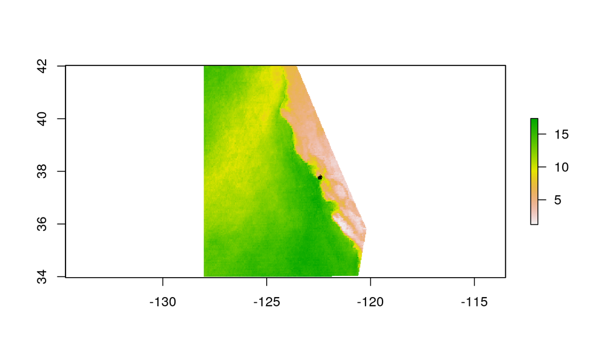

```r
#plot one
plot(karl[[7]])
plot(tracts, add = T)
```

## CRS

What's the projection of the RasterStack?

## CRS

What's the projection of the RasterStack?

```r
#what's the projection?
proj4string(karl)
```

```
## [1] "+proj=longlat +ellps=GRS80 +towgs84=0,0,0,0,0,0,0 +no_defs"
```

## CRS Transformation

Let's reproject this

```r
karl_WGS = projectRaster(karl, projectExtent(karl, CRS(proj4string(tracts))))

# check resultant CRS
proj4string(karl_WGS) == proj4string(tracts)
```

```
## [1] TRUE
```

## What??

What type of spatial object did that give us?

```r
karl_WGS
```

```
## class       : RasterBrick
## dimensions  : 256, 250, 64000, 42  (nrow, ncol, ncell, nlayers)
## resolution  : 0.0314827, 0.0314827  (x, y)
## extent      : -128.0284, -120.1578, 33.96418, 42.02375  (xmin, xmax, ymin, ymax)
## coord. ref. : +proj=longlat +datum=NAD83 +no_defs +ellps=GRS80 +towgs84=0,0,0
## data source : in memory
## names       : flcc1999aug, flcc1999jul, flcc1999jun, flcc1999sep, flcc2000aug, flcc2000jul, flcc2000jun, flcc2000sep, flcc2001jul, flcc2001jun, flcc2001sep, flcc2002aug, flcc2002jul, flcc2002jun, flcc2002sep, ...
## min values  :        1.85,        0.56,        1.69,        0.26,        0.78,        1.05,        1.23,        1.74,        1.29,        1.32,        1.23,        0.30,        1.20,        0.13,        0.86, ...
## max values  :       15.72,       18.56,       17.84,       18.26,       14.84,       18.21,       17.37,       12.18,       20.44,       16.50,       15.20,       17.65,       16.85,       14.87,       14.87, ...
```

## RasterBrick

A RasterBrick. What does that mean?

```r
# See the documentation!
?raster::brick
```

## Crop the Brick

Crop it to the extent of our area of interest - SF

```r
# Crop it to tracts
karl_WGS_crop = crop(karl_WGS, extent(tracts))

#Note that R vectorized that operation across our entire RasterBrick, the same way that it vectorizes many operations, e.g. 3<4 vs 3< seq(4)
```

## Plot it

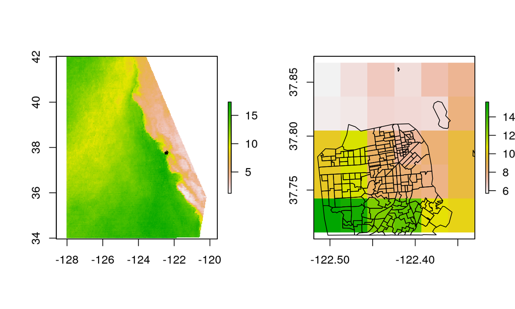

```r
# now let's make our same plot again
par(mfrow = c(1,2))
plot(karl[[7]])
plot(tracts, add = T)
plot(karl_WGS_crop[[7]])
plot(tracts, add = T)
```

## Mean Fog

Let's mean the karl values across the RasterBrick

```r
# Mean values
mean_karl_WGS_crop = mean(karl_WGS_crop)
```

What did that give us?

```r
mean_karl_WGS_crop
```

```
## class       : RasterLayer
## dimensions  : 5, 6, 30  (nrow, ncol, ncell)
## resolution  : 0.0314827, 0.0314827  (x, y)
## extent      : -122.519, -122.3301, 37.71062, 37.86803  (xmin, xmax, ymin, ymax)
## coord. ref. : +proj=longlat +datum=NAD83 +no_defs +ellps=GRS80 +towgs84=0,0,0
## data source : in memory
## names       : layer
## values      : 4.71, 12.3719  (min, max)
```

## RasterBrick to Raster

When we computed the mean of a RasterBrick we got back a RasterLayer object! That makes sense, because we took cellwise means across all Layers in our Brick.

**This is called raster algebra**

## Plot it

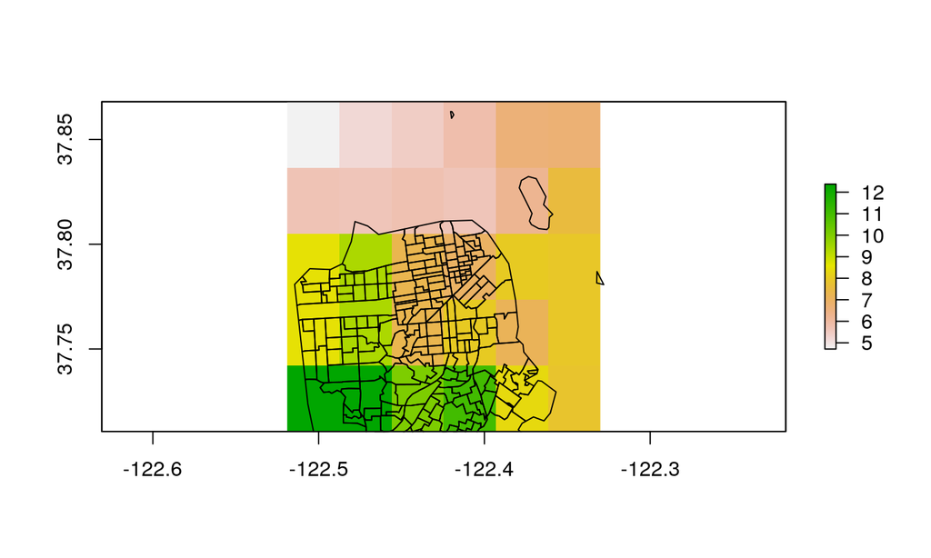

```r
plot(mean_karl_WGS_crop)
plot(tracts, add = T)
```

## BUT

Not all common operations successfully run as raster algebra

```r
# This won't work
sd_karl_WGS_crop = sd(karl_WGS_crop)
```

Let's try this instead

```r
sd_karl_WGS_crop = calc(karl_WGS_crop, sd)
```

## Plot it

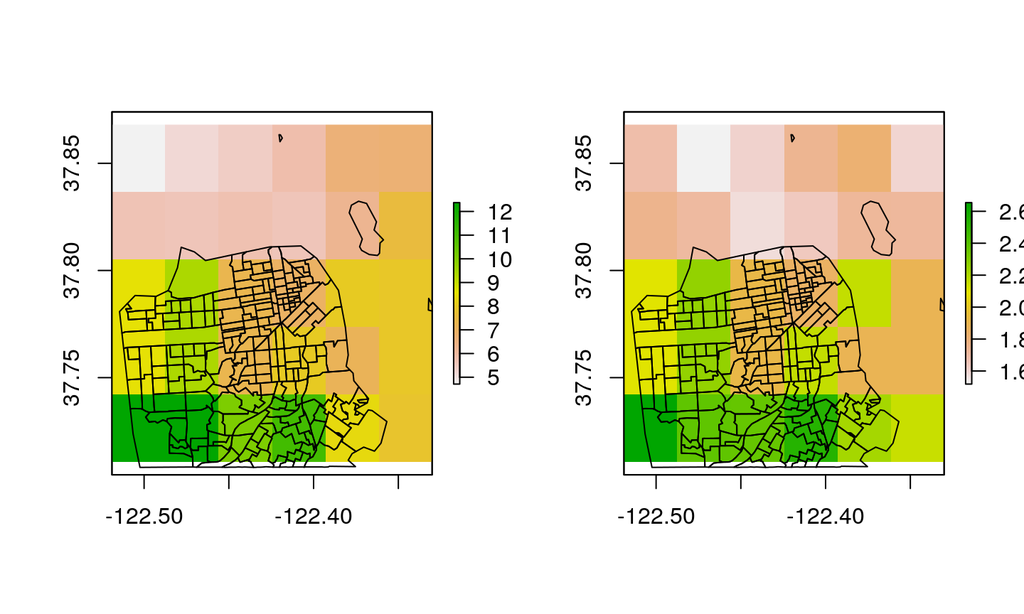

```r
#plot that too
par(mfrow = c(1,2))
plot(mean_karl_WGS_crop)
plot(tracts, add = T)
plot(sd_karl_WGS_crop)
plot(tracts, add = T)
```

## Thoughts…

Looks like the foggiest neighborhoods also have the highest variation in fog, but some less foggy neighborhoods on the east side of the city (e.g. The Inner Mission, Bayview) also vary quite a bit

## Extract Mean Values

Extract fog values to our tracts

```r
tracts$mean_karl = extract(mean_karl_WGS_crop, tracts, mean)
```

## Explore Spatial Relationships

Maybe fogginess is a function of elevation? would make sense, right?

```r
# Linear regression model
mod = lm(mean_karl ~ mean_elev, data = tracts)
```

## View results

```r
summary(mod)
```

```
##
## Call:
## lm(formula = mean_karl ~ mean_elev, data = tracts)
##
## Residuals:
##     Min      1Q  Median      3Q     Max
## -2.0659 -1.2745 -0.3786  0.9346  4.2184
##
## Coefficients:
##             Estimate Std. Error t value Pr(>|t|)
## (Intercept) 7.830075   0.242622  32.273  < 2e-16 ***
## mean_elev   0.009123   0.003334   2.736  0.00685 **
## ---
## Signif. codes:  0 '***' 0.001 '**' 0.01 '*' 0.05 '.' 0.1 ' ' 1
##
## Residual standard error: 1.491 on 180 degrees of freedom
##   (13 observations deleted due to missingness)
## Multiple R-squared:  0.03992,    Adjusted R-squared:  0.03459
## F-statistic: 7.485 on 1 and 180 DF,  p-value: 0.006845
```